# Data Scraping with rves

Schmidt Ana Lucia  
21/10/2019

### Overview

- Intro to HTML
- Data Scraping
- The robots.txt file
- Using `rvest` to Scrap Static Pages
- Practice

### Intro to HTML

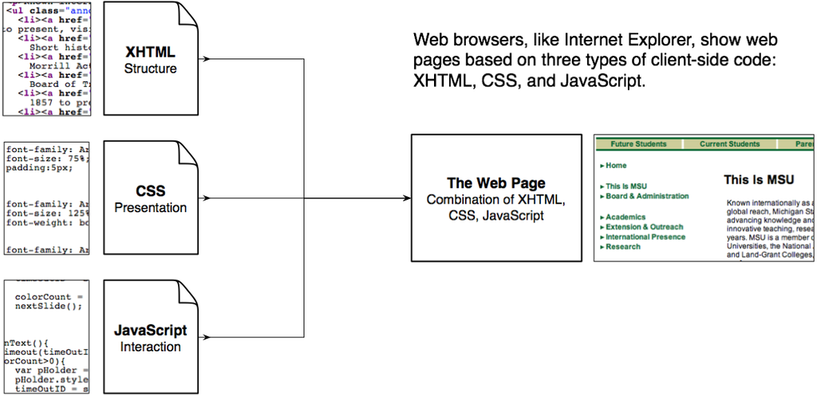

### Intro to HTML

Web scraping, unlike APIs, is a much more brute-force way of obtaining data on the web.

Not all sites have API's to use, which means that it may be necessary to scrape.

Not all sites are set up well for scrapping:

- Badly structured,
- Lots of dynamic content (JavaScript). Much more complex to scrape, but can be done with RSelenium.
- **Request restrictions.**

How would we go about checking if we can scrape a webpage? **We just check the robots.txt file.**

`User-agent: *`

`Allow: /` #allows scraping

### Intro to HTML

```r
All HTML tags take the format... <html> around the content </html>.

- <html> Defines the Web page to be written in HTML.

- <head> Defines the page head.

- <body> Defines the page main content.

- <hN> Defines the heading of level N. Such as h1, h2, etc.

- <b> For <b>bold</b>.

- <i> For <i>italics</b>.

- <ul> Brackets an unordered list (bulletpoints).

- <ol> Brackets an numbered list.

- <p> Starts a paragraph.

- <a href="..."></a> Defines an hyperlink.
```

### Scraping with rvest

There are 2 ways to access the information:

- XPaths: uses “path like” syntax to identify and navigate nodes in an XML document
- CSS: uses attributes like `id` or `class`.

### Scraping with rvest: XPath

XML documents are treated as trees of nodes.

- The topmost element of the tree is the root element.
- Each element and attribute has one parent.

```r
<?xml version="1.0" encoding="UTF-8"?>
<bookstore>
  <book>
    <title lang="en">Harry Potter</title>
    <author>J K. Rowling</author>
    <year>2005</year>
    <price>29.99</price>
  </book>
</bookstore>
```

The book element is the parent of the title, author, year, and price.

### Scraping with rvest: CSS

- CSS stands for Cascading Styling Sheet.
- CSS is a language that describes the style of an HTML document.
- CSS describes how HTML elements should be displayed.
- We make use of attributes to decide how to display specific elements.

### Scraping with rvest

rvest contains the basic web scraping functions, which are quite effective.

- read_html(url) : scrape HTML content from a given URL, converts it into XML
- html_nodes(): identifies HTML wrappers.
- html_nodes(“.class”): calls node based on CSS class
- html_nodes(“#id”): calls node based on the `<div>` id
- html_nodes(xpath=“xpath”): calls node based on xpath
- html_attrs(): identifies attributes (useful for debugging)
- html_table(): turns HTML tables into data frames
- html_text(): strips the HTML tags and extracts only the text

### Scraping with rvest

1. Convert a website into an XML object with the read_html(url) function.
2. Find the respective CSS or Xpath to the element we are interested in.
3. Extract the relevant nodes from the XML object with html_nodes(). The output will be a list of all the nodes found that match the search.
4. Extract the tagged data with html_text() to the nodes you want.
5. For the cases where you need to extract the attributes instead, you apply html_attrs().

### Scraping with rvest: CSS attributes

- Use # in front of 'id' element
- Use . in front of 'class' element
- Use a, div, h1, h2, h3, or body to get into that chunk

### Scraping Wikipedia

```r
library(data.table)
library(rvest)

url = 'https://en.wikipedia.org/wiki/Death_by_coconut'
html = read_html(url)
html
```

```
{xml_document}
<html class="client-nojs" lang="en" dir="ltr">
[1] <head>\n<meta http-equiv="Content-Type" content="text/html; charset= ...
[2] <body class="mediawiki ltr sitedir-ltr mw-hide-empty-elt ns-0 ns-sub ...
```

### Scraping the Wikipedia Title

```r
title =
  read_html(url) %>%
  html_nodes('h1#firstHeading')  %>%
  html_text()
title
```

```
[1] "Death by coconut"
```

### Scraping all the links in a Wikipedia article

```r
links =
  html %>%
  html_node('body #bodyContent') %>%
  html_nodes("a") %>%
  html_attr("href")
head(links)
```

```
[1] "#mw-head"
[2] "#p-search"
[3] "/wiki/File:BEWARE_FALLING_COCONUTS_sign_in_Honolulu_Hawaii-Vector.svg"
[4] "/wiki/File:BEWARE_FALLING_COCONUTS_sign_in_Honolulu_Hawaii-Vector.svg"
[5] "/wiki/Honolulu"
[6] "/wiki/English_language"
```

### Scraping all the links in a Wikipedia article

```r
links = unique(links) # remove duplicate
table(startsWith(prefix = "/wiki", x = links)) # how many are wiki links?
```

```
FALSE  TRUE
  232   110
```

```r
# remove external links -> must start with /wiki/
links = links[grepl(pattern = "/wiki/", x = links)]
head(links, 3)
```

```
[1] "/wiki/File:BEWARE_FALLING_COCONUTS_sign_in_Honolulu_Hawaii-Vector.svg"
[2] "/wiki/Honolulu"
[3] "/wiki/English_language"
```

### Scraping all the links in a Wikipedia article

```r
# remove special wiki links like files or resources
links = links[!grepl(pattern = "/wiki/File:", x = links)] # remove file links
links = links[!grepl(pattern = "/wiki/Special:", x = links)] # remove special links
links = links[!grepl(pattern = "/wiki/Category:", x = links)] # remove category links
links = links[!grepl(pattern = "/wiki/Help:", x = links)] # remove help links
head(links, 12)
```

```
 [1] "/wiki/Honolulu"          "/wiki/English_language"
 [3] "/wiki/Japanese_language" "/wiki/Urban_legend"
 [5] "/wiki/Shark_attack"      "/wiki/Queensland"
 [7] "/wiki/Australia"         "/wiki/Coconut_palm"
 [9] "/wiki/Pinnate"           "/wiki/Trunk_(botany)"
[11] "/wiki/Papua_New_Guinea"  "/wiki/Ig_Nobel_Award"
```

### Scraping a Wikipedia Table

```r
url = 'https://en.wikipedia.org/wiki/G%C3%A4vle_goat'
html = read_html(url)
goat_incidents =
  html %>%
  html_node('table') %>%
  html_table()
table(grepl(pattern = "Survived", x = goat_incidents$`Date of destruction`))
```

```
FALSE  TRUE
   38    15
```

```r
prop.table(table(grepl(pattern = "Survived", x = goat_incidents$`Date of destruction`)))
```

```
    FALSE      TRUE
0.7169811 0.2830189
```

### Scraping a Wikipedia Table of Contents

```r
url = 'https://en.wikipedia.org/wiki/List_of_pigs'
html = read_html(url)
toc =
  html %>%
  html_node('div#toc') %>%
  html_nodes("a")
toc[1]
```

```
{xml_nodeset (1)}
[1] <a href="#General"><span class="tocnumber">1</span> <span class="toc ...
```

```r
toc[5]
```

```
{xml_nodeset (1)}
[1] <a href="#Tirpitz"><span class="tocnumber">1.4</span> <span class="t ...
```

### Scraping a Wikipedia Table of Contents

```r
toc_number = toc %>% html_nodes('span.tocnumber') %>% html_text()
head(toc_number)
```

```
[1] "1"   "1.1" "1.2" "1.3" "1.4" "1.5"
```

```r
toc_title = toc %>% html_nodes('span.toctext') %>% html_text()
head(toc_title)
```

```
[1] "General"      "Unnamed pigs" "Curly Boy"    "King Neptune"
[5] "Tirpitz"      "Max"
```

```r
toc_df = data.frame(toc_number, toc_title)
head(toc_df)
```

```
  toc_number    toc_title
1          1      General
2        1.1 Unnamed pigs
3        1.2    Curly Boy
4        1.3 King Neptune
5        1.4      Tirpitz
6        1.5          Max
```

### Practice!

- Open the Quotse Case Study from the Web Scraping Sandbox http://toscrape.com/.

Scrap some quotes! What fields can we get?

- Go to the [List of Unusual articles in Wikipedia](https://en.wikipedia.org/wiki/Wikipedia:Unusual_articles)

Scrap a list of the articles' title, their categories and their links.

### References

- [HTML Examples](https://www.w3schools.com/html/html_examples.asp)
- [rvest](https://cran.r-project.org/web/packages/rvest/index.html)
- [Web Scraping Sandbox](http://toscrape.com/)
- [XPath Tutorial](https://www.w3schools.com/xml/xpath_intro.asp)